# Report exercise 10

Elias Köppel

2023-05-20

```r
library(dplyr)
library(tidyverse)
```

```r
library(cowplot)
library(ggplot2)
library(recipes)
source("report_exercise_10_functions.R")




davos_flux <- read_csv("C:/Users/elias/OneDrive/Uni/4. Semester/Geo/AGDS I/agds_report_eliaskoeppel/data/FLX_CH-Dav_FLUXNET2015_FULLSET_DD_1997-2014_1-3.csv")
davos_flux <- get_selection(davos_flux)
davos_flux <- davos_flux[, -c(1,8)] #getting rid of P_F because I want to pool the davos data with the laegern data later and in the laegern data all the P_F values are NA. Also I get rid of the Timestamp column because in my laegern data set this coumn does not exist...

laegern_flux <- read_csv("C:/Users/elias/OneDrive/Uni/4. Semester/Geo/AGDS I/agds_report_eliaskoeppel/data/FLX_CH-Lae_FLUXNET2015_FULLSET_DD_2004-2014_1-4.csv")
laegern_flux <- get_selection_laegern(laegern_flux)
laegern_flux <- laegern_flux[,-7] #removing the seventh coulumn because it only consists of NA values

set.seed(1982)


#getting splits for davos data
split1 <- rsample::initial_split(davos_flux, prop = 0.8, strata = "VPD_F")

davos_flux_train <- rsample::training(split1)

davos_flux_test <- rsample::testing(split1)


#getting splits for laegern data
split2 <- rsample::initial_split(laegern_flux, prop = 0.8, strata = "VPD_F")

laegern_flux_train <- rsample::training(split2)

laegern_flux_test <- rsample::testing(split2)


# pre-processing with the get_pp function I stored in the extra file
pp_davos_train <- get_pp(davos_flux_train)
pp_davos_test <- get_pp(davos_flux_test)

pp_laegern_train <- get_pp(laegern_flux_train)
pp_laegern_teset <- get_pp(laegern_flux_test)
```

k-fold cross validation for the davos_flux_train data:

```r
set.seed(1982)
mod_cv_davos_train <- caret::train(pp_davos_train,
                       data = davos_flux_train |> drop_na(),
                       method = "knn",
                       trControl = caret::trainControl(method = "cv", number = 10))
```

k-fold cross validation for the laegern_flux_train data:

```r
set.seed(1982)
mod_cv_laegern_train <- caret::train(pp_laegern_train,
                       data = laegern_flux_train |> drop_na(),
                       method = "knn",
                       trControl = caret::trainControl(method = "cv", number = 10))
```

```r
plot_1 <- eval_model(mod = mod_cv_davos_train, df_test = davos_flux_test)
```

```r
plot_2 <- eval_model(mod = mod_cv_davos_train, df_test = laegern_flux_test)
```

In the following plot we see:

On the left: how the cv model of the davos train set performs on the davos test set (within-site).

On the right: how the cv model of the davos train set performs on the laegern test set (across-site).

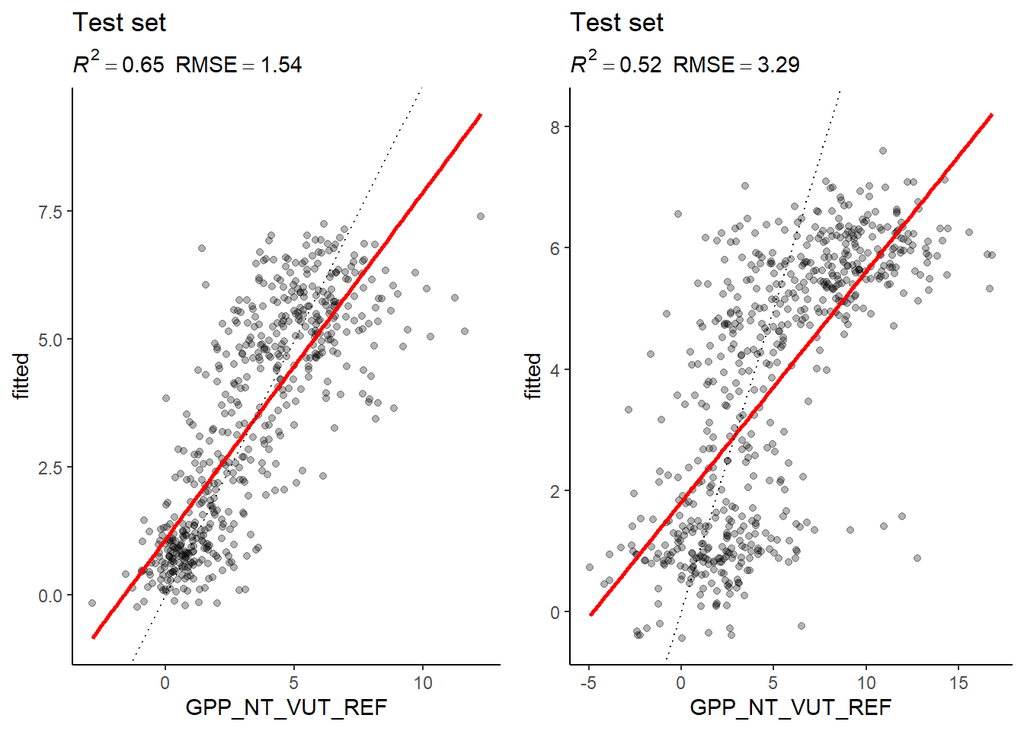

```r
cowplot::plot_grid(plot_1, plot_2)
```

```r
plot_3 <- eval_model(mod = mod_cv_laegern_train, df_test = laegern_flux_test)
```

```r
plot_4 <- eval_model(mod = mod_cv_laegern_train, df_test = davos_flux_test)
```

In the following plot we see:

On the left: how the cv model of the laegern train set performs on the laegern test set (within-site).

On the right: how the cv model of the laegern train set performs on the davos test set (across-site).

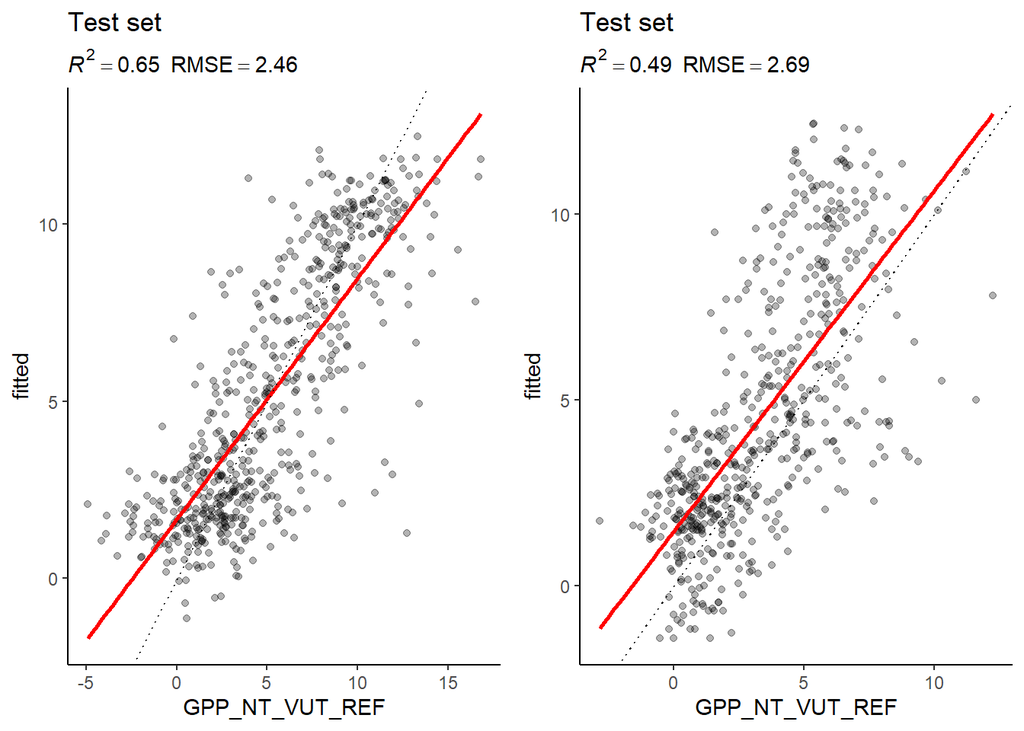

```r
cowplot::plot_grid(plot_3, plot_4)
```

Pooling data and creating subsets, with which I create a single model

```r
data_pooled <- rbind(davos_flux, laegern_flux)




set.seed(1982)


#getting splits for davos data
split3 <- rsample::initial_split(data_pooled, prop = 0.8, strata = "VPD_F")

data_pooled_train <- rsample::training(split3)

data_pooled_test <- rsample::testing(split3)





# pre-processing with the get_pp function I stored in the extra file
pp_data_pooled_train <- get_pp(data_pooled_train)
pp_data_pooled_test <- get_pp(data_pooled_test)




#creating model
set.seed(1982)
mod_data_pooled_train <- caret::train(pp_data_pooled_train,
                       data = data_pooled_train |> drop_na(),
                       method = "knn",
                       trControl = caret::trainControl(method = "cv", number = 10))
```

applying the pooled model to the test data sets of both sites

```r
plot_5 <- eval_model(mod = mod_data_pooled_train, df_test = davos_flux_test)
```

```r
plot_6 <- eval_model(mod = mod_data_pooled_train, df_test = laegern_flux_test)
```

In the following plot we see:

On the left: how the model of the pooled data set performs on the davos test set.

On the right: how the model of the pooled data set performs on the leagern test set.

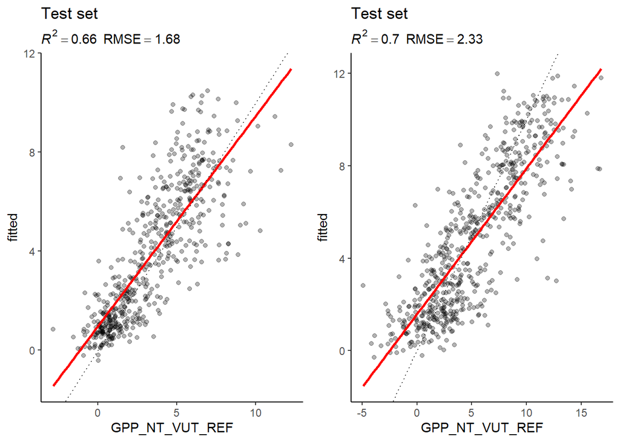

```r
cowplot::plot_grid(plot_5, plot_6)
```

Interpretation of differences between the performance of the pooled data model and the true out-of-sample setup above.

Site characteristics:

Davos: Elevation: 1639 Climate Koeppen: ET (Tundra) Mean Annual Temp (?C): 2.8 Mean Annual Precip. (mm): 1062 Vegetation IGBP: ENF (Evergreen Needleleaf Forests: Lands dominated by woody vegetation with a percent cover >60% and height exceeding 2 meters. Almost all trees remain green all year. Canopy is never without green foliage.)

Laegern: Elevation: 689 Climate Koeppen: – Mean Annual Temp (?C): 8.3 Mean Annual Precip. (mm): 1100 Vegetation IGBP: MF (Mixed Forests: Lands dominated by trees with a percent cover >60% and height exceeding 2 meters. Consists of tree communities with interspersed mixtures or mosaics of the other four forest types. None of the forest types exceeds 60% of landscape.)

Differences: Main difference is the elevation and connected to that the mean temperature and the types of vegetation. In Davos there are mainly evergreen needle leaf forest whereas in Laegern there are mixed forests.

Biases of the out-of-sample predictions:

If I compare the across-site predictions, I can observe that the Laegern model returns higher values that the Davos model. This might be the case because the Laegern model was trained with higher GPP values than the Davos model, due to the different biological conditions in the different sites (as shown above).